### Gene Overview Statistics

DESCRIPTION

This gene overview displays some general data and distributions related to the genes stored in RegulonDB.

Download Image

Download Data

| Description | Total |
| --- | --- |
| Total of genes in the chromosome | 4748 |
| Type of genes: |  |
| --- phantom | 61 |
| --- pseudo | 147 |
| --- genes | 4540 |
| Total of genes products | 4664 |
| Type of genes products: |  |
| --- rRNA | 22 |
| --- small RNA | 83 |
| --- tRNAs | 86 |

[output cut: 7 more lines]

### Gene Size

This section elucidates the spectrum of gene sizes in *E.coli*. The sizes, calculated for each individual gene, are grouped into specific size ranges, which are detailed in the accompanying table. To provide a visual representation of these size ranges and their prevalence, a graph displaying the frequency of each range is also included.

Download Image

Download Data

| Size of Genes | Total |
| --- | --- |
| 1-100 | 258 |
| 101-200 | 237 |
| 201-300 | 340 |
| 301-400 | 321 |
| 401-500 | 313 |
| 501-600 | 314 |
| 601-700 | 319 |
| 701-800 | 338 |
| 801-900 | 321 |
| 901-1000 | 339 |

[output cut: 39 more lines]

Download Graphic

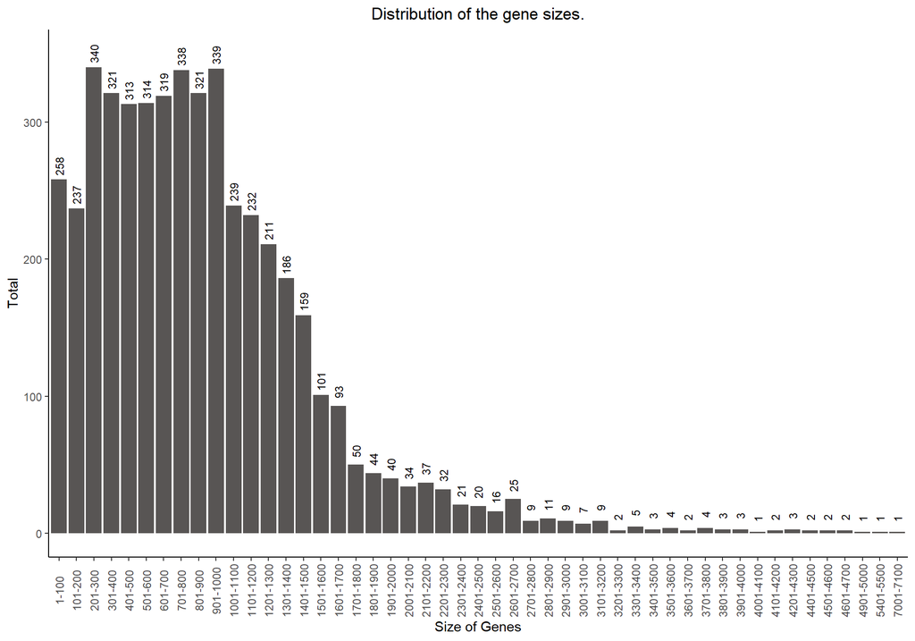

### Distribution of the Number of Transcription Factors Regulating Genes

At RegulonDB, we archive detailed information on gene regulation. Transcription factors (TFs) bind to the promoter region, thereby regulating the transcriptional unit, which comprises a promoter with binding sites, a set of transcribed genes, and a terminator region where the transcription process concludes. This section provides a count of how many regulators or TFs are involved in the transcription of the genes.

Download Image

Download Data

| Total of Genes | Total of TFs that regulate the gene |
| --- | --- |
| 1103 | 1 |
| 632 | 2 |
| 381 | 3 |
| 262 | 4 |
| 143 | 5 |
| 133 | 6 |
| 52 | 7 |
| 25 | 8 |
| 17 | 9 |
| 18 | 10 |

[output cut: 10 more lines]

Download Graphic

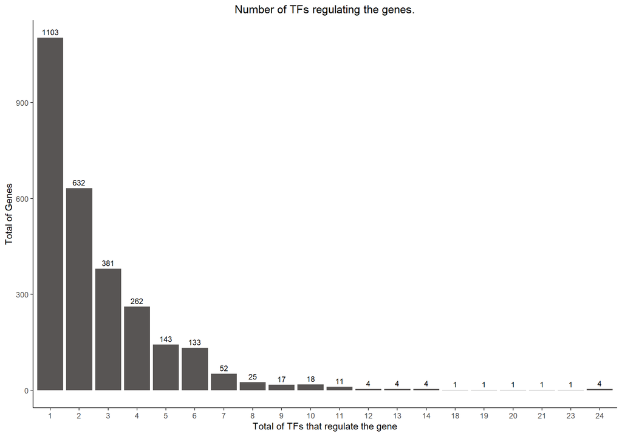

### Distribution of the Number of TUs and Promoters by Gene

#### Distribution of Total promoters per gene

Download Image

Download Data

| Total of Genes | Total of Promoters for gene |
| --- | --- |
| 1546 | 1 |
| 631 | 2 |
| 290 | 3 |
| 192 | 4 |
| 53 | 5 |
| 27 | 6 |
| 41 | 7 |
| 21 | 8 |
| 5 | 9 |
| 14 | 11 |

[output cut: 1 more lines]

#### Distribution of Total Transcription Units (TUs) per gene.

Download Image

Download Data

| Total of Genes | Total of TUs for gene |
| --- | --- |
| 3409 | 1 |
| 612 | 2 |
| 269 | 3 |
| 83 | 4 |
| 76 | 5 |
| 23 | 6 |
| 10 | 7 |
| 17 | 8 |
| 16 | 9 |
| 8 | 10 |

Download Graphic

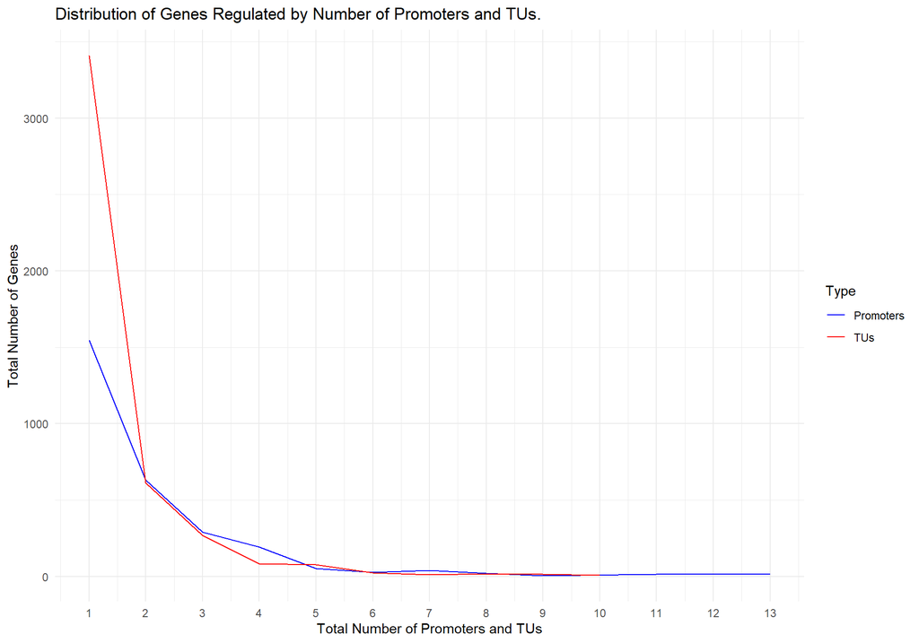

### Distribution of Sigma Factor Regulatory Genes

Download Image

Download Data

| Total of Genes | Total of sigma factors regulating genes |
| --- | --- |
| 1714 | 1 |
| 470 | 2 |
| 44 | 3 |
| 6 | 4 |

Download Graphic

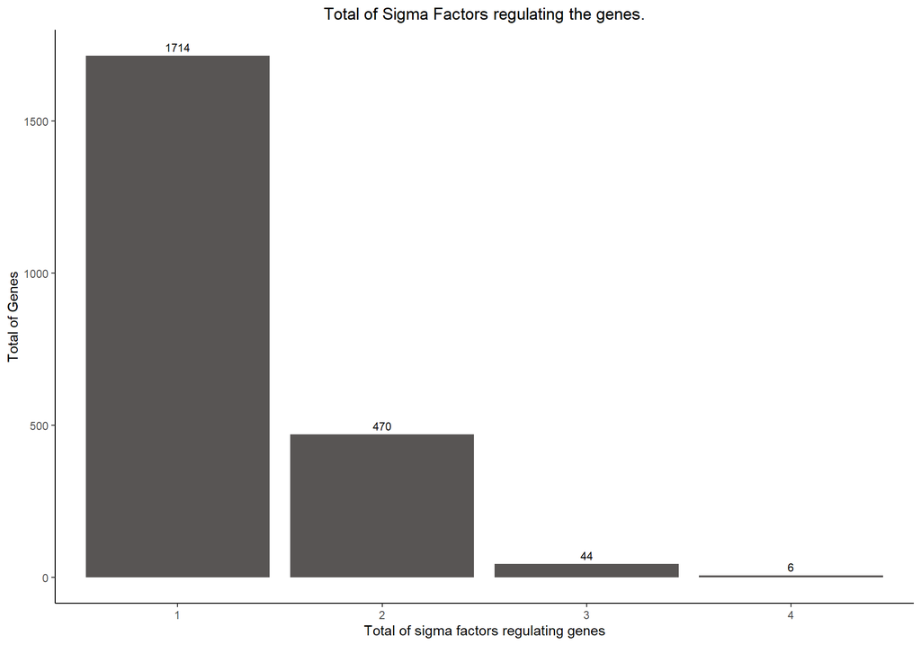

### Distribution of the Number of Functional Classes by Gene

#### Table of Number of Molecular Function Classes by Gene

Download Data

| Class Molecular Function | Total of Genes |
| --- | --- |
| GO:0005515 - protein binding | 1237 |
| GO:0046872 - metal ion binding | 710 |
| GO:0016740 - transferase activity | 585 |
| GO:0000166 - nucleotide binding | 526 |
| GO:0003677 - DNA binding | 523 |
| GO:0042802 - identical protein binding | 505 |
| GO:0016787 - hydrolase activity | 493 |
| GO:0005524 - ATP binding | 447 |
| GO:0016491 - oxidoreductase activity | 360 |
| GO:0042803 - protein homodimerization activity | 344 |

[output cut: 2237 more lines]

Download Graphic

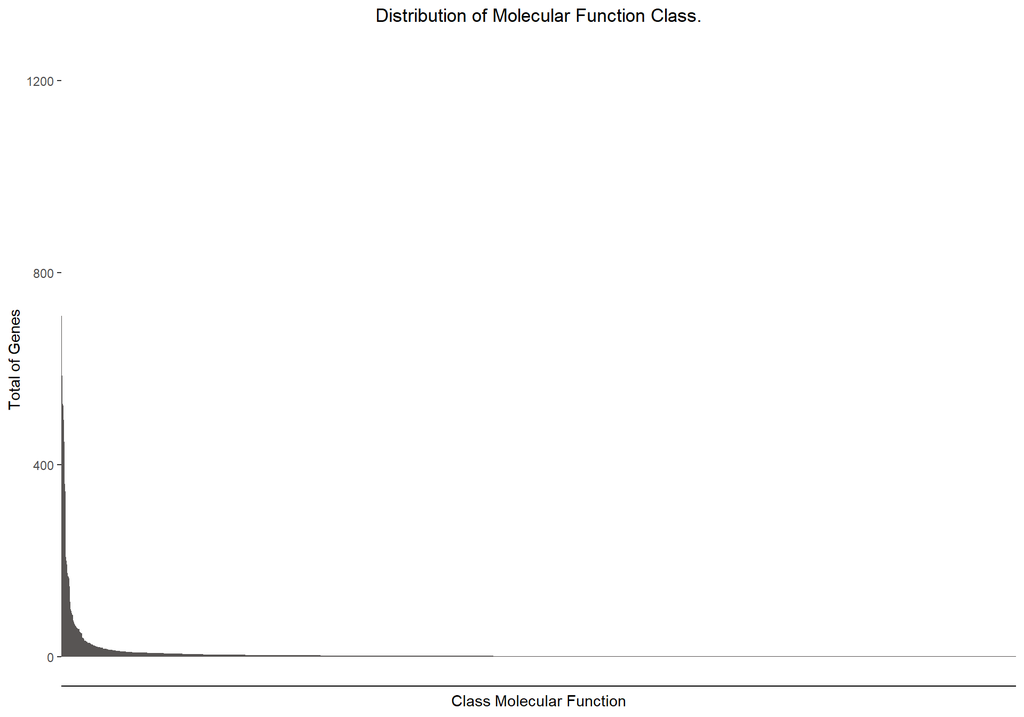

#### Table of Number of Cellular Component Classes by Gene

Download Data

| Class Cellular Component | Total of Genes |
| --- | --- |
| GO:0005829 - cytosol | 2545 |
| GO:0016020 - membrane | 1496 |
| GO:0005886 - plasma membrane | 1326 |
| GO:0005737 - cytoplasm | 1082 |
| GO:0030288 - outer membrane-bounded periplasmic space | 299 |
| GO:0042597 - periplasmic space | 186 |
| GO:0055052 - ATP-binding cassette (ABC) transporter complex, substrate-binding subunit-containing | 150 |
| GO:0009279 - cell outer membrane | 143 |
| GO:0043190 - ATP-binding cassette (ABC) transporter complex | 131 |
| GO:0032991 - protein-containing complex | 92 |

[output cut: 278 more lines]

Download Graphic

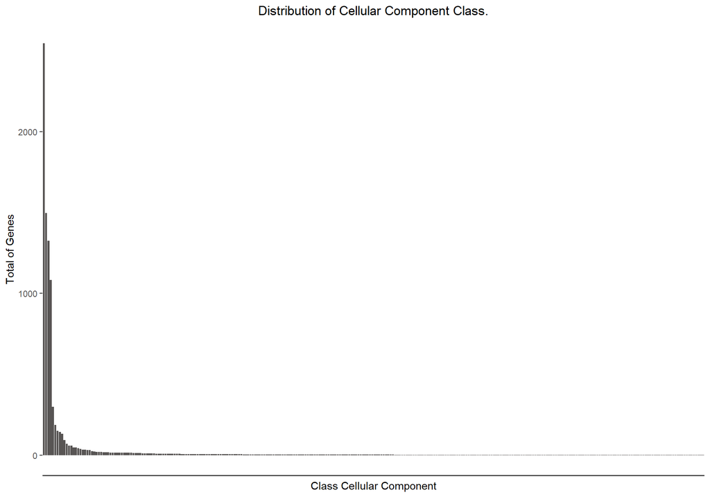

#### Table of Number of Biological Processes by Gene

Download Data

| Class Biological Process | Total of Genes |
| --- | --- |
| GO:0055085 - transmembrane transport | 390 |
| GO:0006355 - regulation of DNA-templated transcription | 313 |
| GO:0006974 - DNA damage response | 253 |
| GO:0016310 - phosphorylation | 170 |
| GO:0008152 - metabolic process | 132 |
| GO:0006412 - translation | 127 |
| GO:0006351 - DNA-templated transcription | 122 |
| GO:0045892 - negative regulation of DNA-templated transcription | 120 |
| GO:0071702 - organic substance transport | 119 |
| GO:0006811 - monoatomic ion transport | 118 |

[output cut: 1946 more lines]

Download Graphic

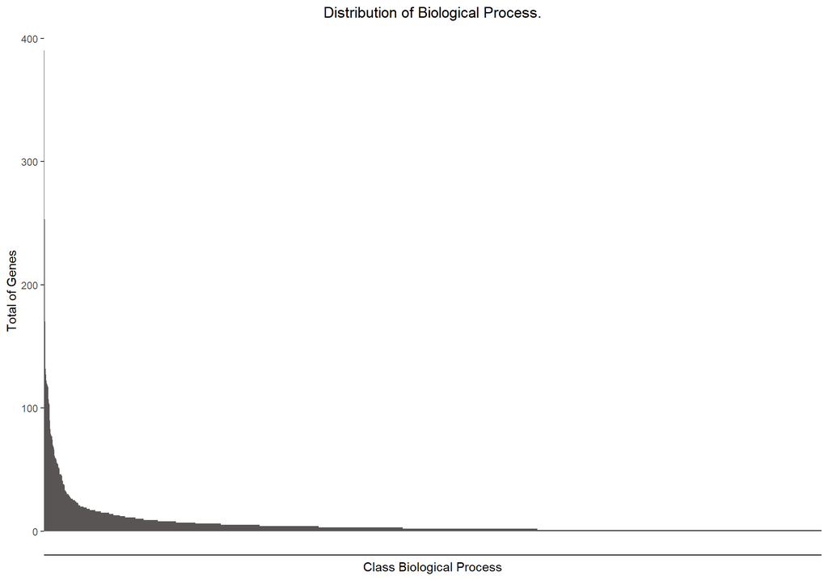